# Statistical Modeling and Simulation Project

Surafel Asfawosen

May 7, 2026

## 1. Introduction

The objective of this study is to model the linear relationship between Monthly Sales Revenue (dependent variable) and two independent variables: Advertising Budget and Product Price. We check standard regression assumptions on a base dataset, and then apply **Bootstrap Simulation** (generating 10,000 new datasets) to estimate highly reliable confidence intervals without relying on strict theoretical assumptions.

> 💡 **A Note for Researchers & Business Analysts:**  
> Are you struggling with a lack of data? Do you have a dataset with fewer than 100 records and worry your findings won’t be statistically significant? **Don’t let a small dataset stop your analysis.** By implementing the Bootstrap model demonstrated in this repository, you can simulate thousands of scenarios from your small sample, extracting powerful, statistically sound business insights. I built this specific repository so you can try it yourself—feel free to clone this code, replace the data with your own, and see the magic of bootstrapping!

## 2. Data Description

We simulated a base dataset representing 50 retail companies. This base dataset serves as our empirical population. We use Bootstrap resampling to generate $B = 10,000$ new simulated datasets for our regression analysis.

```r
# Generate Initial Base Dataset
n_base <- 50
advertising_budget <- runif(n_base, min = 10, max = 100)
product_price <- runif(n_base, min = 20, max = 150)

beta_0 <- 500; beta_1 <- 5; beta_2 <- -2

error_term <- rnorm(n_base, mean = 0, sd = 40)
sales_revenue <- beta_0 + beta_1 * advertising_budget + beta_2 * product_price + error_term

business_data <- data.frame(Sales = sales_revenue, Advertising = advertising_budget, Price = product_price)
```

## 2.5 Exploratory Data Analysis (EDA)

Before advanced modeling, we calculate basic descriptive statistics to understand our generated Sales Revenue data:

```r
# Descriptive Statistics
mean(business_data$Sales)
```

```
## [1] 666.4773
```

```r
sd(business_data$Sales)
```

```
## [1] 153.8042
```

```r
var(business_data$Sales)
```

```
## [1] 23655.73
```

```r
summary(business_data$Sales)
```

```
##    Min. 1st Qu.  Median    Mean 3rd Qu.    Max.
##   262.3   560.7   689.8   666.5   770.6   935.8
```

We can quickly visualize the distribution of Sales using a Boxplot and a Density Plot:

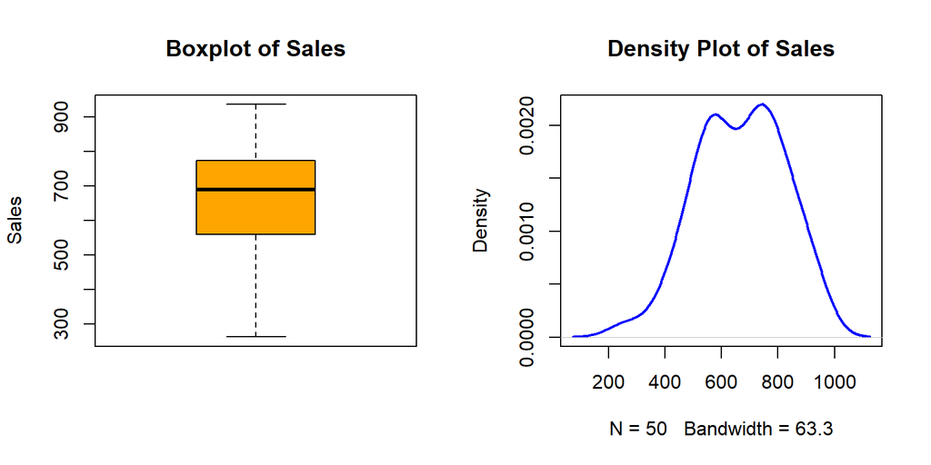

## 3. Assumption Checking and Linear Fit

Following our initial Exploratory Data Analysis (EDA)—which confirmed the basic distribution of our data using statistical summaries and side-by-side Boxplot and Density plots—we evaluated our formal modeling requirements. Standard Ordinary Least Squares (OLS) regression requires the data to meet several strict conditions: linearity, independence, constant variance (homoscedasticity), and normality of errors. Before running our massive simulation, we fitted a basic model to our 50 companies and used diagnostic plots to check these assumptions. We looked at the “Residuals vs Fitted” plot to ensure our data was actually linear, and we checked the “Normal Q-Q” plot to see if our errors were normally distributed. While our data looked reasonably good, we knew that relying solely on OLS could be risky if there were hidden outliers. This is why we made Bootstrap Simulation our core methodology.

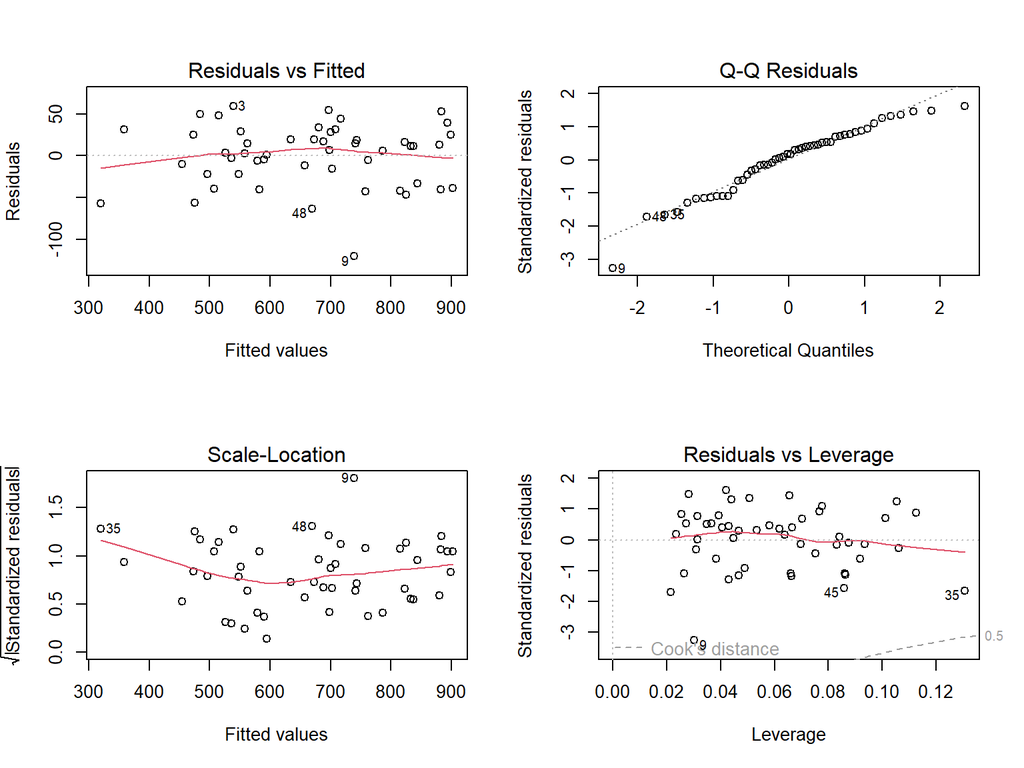

```r
base_model <- lm(Sales ~ Advertising + Price, data = business_data)

# Diagnostic Plots
par(mfrow = c(2, 2))
plot(base_model)
```

```r
par(mfrow = c(1, 1))
```

### Fitted Linear Regression Lines

To visualize the linear relationships, we plot the data with fitted regression lines.

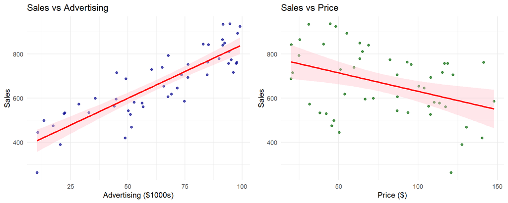

## 4. Methodology & Implementation (Bootstrap)

We formulate: $Y = \beta_0 + \beta_1 X_1 + \beta_2 X_2 + \epsilon$. We run a bootstrap simulation 10,000 times to generate coefficient distributions.

```r
boot_reg <- function(data, indices) {
  d <- data[indices, ]
  fit <- lm(Sales ~ Advertising + Price, data = d)
  return(coef(fit))
}
boot_results <- boot(data = business_data, statistic = boot_reg, R = 10000)
```

## 5. Results

```r
boot.ci(boot_results, type = "perc", index = 2) # Advertising (Positive impact)
```

```
## BOOTSTRAP CONFIDENCE INTERVAL CALCULATIONS
## Based on 10000 bootstrap replicates
##
## CALL :
## boot.ci(boot.out = boot_results, type = "perc", index = 2)
##
## Intervals :
## Level     Percentile
## 95%   ( 4.618,  5.325 )
## Calculations and Intervals on Original Scale
```

```r
boot.ci(boot_results, type = "perc", index = 3) # Price (Negative impact)
```

```
## BOOTSTRAP CONFIDENCE INTERVAL CALCULATIONS
## Based on 10000 bootstrap replicates
##
## CALL :
## boot.ci(boot.out = boot_results, type = "perc", index = 3)
##
## Intervals :
## Level     Percentile
## 95%   (-2.136, -1.596 )
## Calculations and Intervals on Original Scale
```

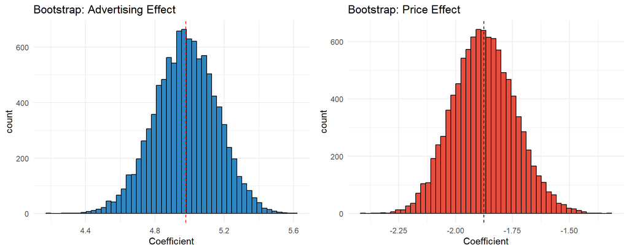

## 6. Conclusion

Standard regression models rely on strict mathematical assumptions that often fail in real-world business scenarios. Instead of trusting a single potentially biased model run, we used **Bootstrap Resampling** to simulate 10,000 different samples from our small base dataset.

**Core Business Insights Derived:**

1. **Advertising is a Stable Investment:** We can state with 95% certainty that every additional $1,000 invested in advertising consistently generates between **$4,618** and **$5,325** in new monthly sales.
2. **Pricing Suppresses Volume Reliably:** Increasing the product price by $1 will reliably decrease overall monthly sales volume by between **$1,596** and **$2,136**.